# Regular expressions

Author

Affiliation

Rosa Karlić

Bioinformatics group

## **Regular Expressions**

[figure not shown]

### **What are Regular Expressions?**

*Regex* are minimal *strings* that represent a **pattern**.  
Such strings contain **special characters** that can represent:

- **Boolean Operations**
- **Grouping**
- **Quantification**
- **Wildcards**

### Some History

Regex were born in theoretical computer science during the early 50s as part of the description of ‘Regular language’ coined by Stephen Kleene.

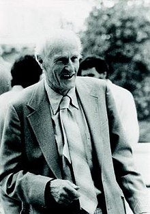

They started as a representation of more complex diagrams used in the field and in theoretical linguistics.

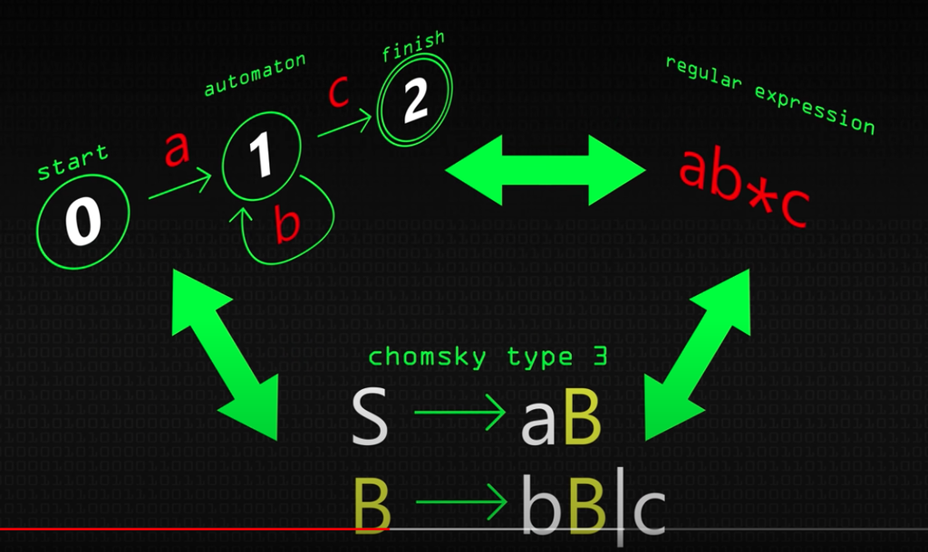

In the late 60’s they started to be implemented in text processors, being **ed** one of the most popular at the time. This was followed by **vi**, **AWK**, **Emacs** the next decade.

Then in the 80’s… **PERL** happened… And it’s dominance for language processing is still at large.

[figure not shown]

### Use of regular expressions

Text search and manipulation in editors and IDEs (e.g., VSCode, Sublime Text).

Data validation (emails, phone numbers).

Log file parsing and monitoring.

Web scraping and data extraction.

Programming languages: Python, R, Perl, JavaScript, and many more.

Command-line tools and shell scripting for automation.

### Regular expressions in bioinformatics

**File parsing & data extraction:**

FASTA/FASTQ file processing: extracting headers, filtering sequences.

GFF/GTF annotation files: extracting gene features.

VCF (Variant Call Format) files: parsing variant info fields.

**Sequence pattern searching:**

Motif detection (e.g., promoter elements, restriction sites).

Detecting ambiguous nucleotide codes.

**Data cleaning:** standardizing metadata fields in sequencing experiment descriptions.

Regular expressions can also be used in R. Let’s explore its potential.

## **grep**

Grep is the most common name for matching patterns with regex. It exists just as **grep** in base R but be aware that there are many variants of it.

### What does grep mean?

**g/re/p** meaning “Global search for Regular Expression and Print matching lines”

### How to use it?

```r
grep("pattern", YourStringOfInterest)
```

### Play with it!

```r
#grep(, )
```

### Let’s get some data.

```r
reg.exmpl <- c("krava", "plava", "prava", "plavac","tava", "vatra", "bla", "blabla", "blablabla",
               "abcabcabc", "abcblaabc", "blaXblaX", "abcYabc", "abc1z", "abc4z","plllava",
               "pava", "XX","XnblaX")
```

Problem: We want to find all words that contain the substring “va”.

## **Anchors**

^ $: Starting or ending with substring

[output not shown]

Symbol ^ represents beginning of the string:

```r
grep("^va", reg.exmpl, value=T)
```

```
[1] "vatra"
```

Symbol $ represents end of the string:

```r
grep("ra$", reg.exmpl, value=T)
```

```
[1] "vatra"
```

1. Get all the words that contain the substring “bla”.
2. Get all the words that START with substring “bla”.
3. Get all the words that END with substring “bla”.

## **Wildcards**

We want to find all words that look like: “p” followed by any one character, followed by “ava”.

Go ahead!

There are many more WILDCARD characters, some of them are to represent things as **any digit** or **any letter**. You’ll need to check for your homework.

### Restrict your options

If we want to find words containing lava or tava as a substring, we can write that as:

```r
grep("[lt]ava", reg.exmpl, value=T)
```

```
[1] "plava"   "plavac"  "tava"    "plllava"
```

Here, [lt] represents ONE character - either l or t in this position. Sets of characters enclosed in square brackets [] are called character classes. The pattern will match any single character that belongs to that set.

## **Quantification Characters**

When we don’t know the number of occurrences of some character, we can use special symbols to describe what we expect:

? - zero or one  
+ - one or more  
* - zero or more

```r
lll <- c("Eample1","Example1", "Exxample1", "Exxxample1")
lll
```

```
[1] "Eample1"    "Example1"   "Exxample1"  "Exxxample1"
```

For example:

```r
grep("Ex?ample1", lll, value = T)
```

```
[1] "Eample1"  "Example1"
```

```r
grep("Ex+ample1", lll, value = T)
```

```
[1] "Example1"   "Exxample1"  "Exxxample1"
```

```r
grep("Ex*ample1", lll, value = T)
```

```
[1] "Eample1"    "Example1"   "Exxample1"  "Exxxample1"
```

When we know the number of occurrences of some character, we can use this:

{n} - this symbol appears here exactly n times in a row

{n, m} - this symbol appears here from n to m times in a row

What do you expect to get now?

```r
grep("x{2}", lll, value = T)
```

```
[1] "Exxample1"  "Exxxample1"
```

```r
grep("x{0,2}", lll, value = T)
```

```
[1] "Eample1"    "Example1"   "Exxample1"  "Exxxample1"
```

```r
grep("x{2}a", lll, value = T)
```

```
[1] "Exxample1"  "Exxxample1"
```

```r
grep("Ex{2}a", lll, value = T)
```

```
[1] "Exxample1"
```

## **Special Characters**

What if we want to find “?”?  
Look at the following example:

```r
primjer2 <- c("How","to", "find ", "a", "question", "mark?")
primjer2
```

```
[1] "How"      "to"       "find "    "a"        "question" "mark?"
```

Since ? is a special character, if we try to use it like this:

```r
grep("?", primjer2,value=T)
```

```
[1] "How"      "to"       "find "    "a"        "question" "mark?"
```

```r
grep("\\?", primjer2,value=T)
```

```
[1] "mark?"
```

## **Exclude characters**

If you want to find a character that is NOT some character, use “[^ ]”

```r
reg.exmpl
```

```
 [1] "krava"     "plava"     "prava"     "plavac"    "tava"      "vatra"
 [7] "bla"       "blabla"    "blablabla" "abcabcabc" "abcblaabc" "blaXblaX"
[13] "abcYabc"   "abc1z"     "abc4z"     "plllava"   "pava"      "XX"
[19] "XnblaX"
```

```r
grep(".ava", reg.exmpl, value = T)
```

```
[1] "krava"   "plava"   "prava"   "plavac"  "tava"    "plllava" "pava"
```

```r
grep("[^l]ava", reg.exmpl, value = T)
```

```
[1] "krava" "prava" "tava"  "pava"
```

## **Groups**

When we want to find groups of characters, we can do it like this:

```r
primjer <- c("GRP1", "GRP2", "GRP3","GRP1GRP2", "GRP1GRP3", "GRP2GRP3", "GRP1GRP1GRP2", "GRP1GRP1GRP3", "GRP1GRP2GRP3","GRP2GRP3","GRP2GRP1GRP2", "GRP2GRP1GRP3", "GRP2GRP2GRP3", "GRP3GRP1GRP2", "GRP3GRP1GRP3", "GRP3GRP2GRP3", "GRP1GRP2GRP1GRP3", "GRP1GRP2GRP2GRP3", "GRP1GRP3GRP2GRP3")
primjer <- sort(unique(primjer))
primjer
```

```
 [1] "GRP1"             "GRP1GRP1GRP2"     "GRP1GRP1GRP3"     "GRP1GRP2"
 [5] "GRP1GRP2GRP1GRP3" "GRP1GRP2GRP2GRP3" "GRP1GRP2GRP3"     "GRP1GRP3"
 [9] "GRP1GRP3GRP2GRP3" "GRP2"             "GRP2GRP1GRP2"     "GRP2GRP1GRP3"
[13] "GRP2GRP2GRP3"     "GRP2GRP3"         "GRP3"             "GRP3GRP1GRP2"
[17] "GRP3GRP1GRP3"     "GRP3GRP2GRP3"
```

If we want to work on a group of characters, put them in round brackets!

All words where “GRP1” is repeated 2 times in a row:

```r
grep("(GRP1){2}", primjer, value=T)
```

```
[1] "GRP1GRP1GRP2" "GRP1GRP1GRP3"
```

All words where “GRP1” is repeated 1 or more times before GRP2 :

```r
grep("(GRP1)+(GRP2)", primjer, value=T)
```

```
[1] "GRP1GRP1GRP2"     "GRP1GRP2"         "GRP1GRP2GRP1GRP3" "GRP1GRP2GRP2GRP3"
[5] "GRP1GRP2GRP3"     "GRP2GRP1GRP2"     "GRP3GRP1GRP2"
```

## **Functions that use regular expressions**

**grepl(pattern, x)**: Returns TRUE/FALSE if pattern found

**grep(pattern, x)**: Returns indices of matches

**regexpr(pattern, x)**: Returns position of first match

**gregexpr(pattern, x)**: Positions of all matches

**sub(pattern, replacement, x)**: Replace first match

**gsub(pattern, replacement, x)**: Replace all matches

```r
seq <- c("ATGCGTA", "CGTTGA", "ATATAT", "GCGCGC")
# Find sequences with CG dinucleotide
grepl("CG", seq)
```

```
[1]  TRUE  TRUE FALSE  TRUE
```

```r
# [1] TRUE TRUE FALSE TRUE
```

Example 2: Transcribing DNA to mRNA with gsub()

```r
dna_seq <- "ATGCGTACGTTAG"

# Replace all 'T' with 'U' using gsub for full transcription
mrna_seq <- gsub("T", "U", dna_seq)

print(mrna_seq)
```

```
[1] "AUGCGUACGUUAG"
```

```r
# Output: "AUGCGUACGUUAG"
```

Example 3: Finding the Position of a Transcription Factor (TF) Binding Site with regexpr()

```r
dna_seq <- "GCGTATATAGCGCGTATAAGT"

# Find position of first TATA box using regexpr
pos <- regexpr("TATA", dna_seq)

print(pos)          # Starting position of first match
```

```
[1] 4
attr(,"match.length")
[1] 4
attr(,"index.type")
[1] "chars"
attr(,"useBytes")
[1] TRUE
```

```r
print(attr(pos, "match.length"))  # Length of the match
```

```
[1] 4
```

```r
# Extract the matched sequence
binding_site <- regmatches(dna_seq, pos)
print(binding_site)  # Should print "TATA"
```

```
[1] "TATA"
```

## Exercises

1. Find all sequences starting with ATG and followed by any three nucleotides.

```r
seqs <- c("ATGAAA", "ATGCCC", "ATG", "GGGATG")
# Your code here
```

2. Extract all stretches of exactly three or four A’s (A{3,4}) in the following DNA sequences.

```r
seqs <- c("AAATTT", "AAAAT", "AAAAA", "TTTAAAG")
# Your code here
```

3. Replace the first stretch of G’s (one or more) with X in the following sequences.

```r
seqs <- c("GGATGC", "GGAAGG", "AGGCGG")
# Your code here
```

4. Check which sequences contain any character other than A, T, C, or G (e.g., ambiguous nucleotide N).

```r
seqs <- c("ATGCN", "GGCCA", "TTANT")
# Your code here
```

5. Find sequences ending with a stop codon (TAA, TAG, or TGA).

```r
seqs <- c("ATGCCCTAA", "ATGCCCTAG", "ATGCCCTGA", "ATGCCC")
# Your code here
```